# 05-02. 성향점수 (이중 강건 추정, 일반화 성향 점수)

## 05.04. 디자인 vs. 모델 기반 식별

- 회귀분석 또는 IPW 중 언제 어떤 방법을 사용해야 하는가?

  **이 선택은 모델 기반 (Model Based) 식별과 디자인 기반 (Design Based)식별에 관한 문제**

#### 모델 기반 식별 (Model Based Identification)

- **이 방식의 주인공은 결과 $Y$**
- **핵심 아이디어 : 변수 $X$들을 가지고 결과 $Y$를 완벽하게 예측하는 공식을 만들 수 있다면, 처치를 안 받은 사람이 처치를 받았을 때 어떤 결과가 나왔을지도 예측할 수 있다**

  $\rightarrow$ **회귀분석 ($Y = f(T, X)$) 모델링**
- **목표 : 데이터에 없는 잠재적 결과 (Counterfactual)을 모델로 계산하여 채워넣는 것이 목표**
- 단점 : 만약 내가 세운 모델 자체가 실제와 거리가 멀다면, 결과는 완전히 틀리게 됨

#### 디자인 기반 식별 (Design Based Identification)

- **이 방식의 주인공은 처치 배정 ($T$)**
- **핵심 아이디어 : 누가 처치를 받았는지 그 과정 (매커니즘)만 정확히 안다면, 데이터를 재구성해서 무작위 실험(RCT)처럼 나들 수 있다**

  $\rightarrow$ **IPW (처치가 어떻게 배정되었는지(성향점수)를 모델링하고, 그 역수를 곱해 균형을 맞춤)**
- **목표 : 데이터의 처치 배정 디자인을 수정하여, 실험군과 대조군을 비교 가능한 상태로 만드는 것**
  - 결과$Y$가 얼마나 복잡하게 결정되는 지는 몰라도, 처치 $T$가 결정되는 과정만 잘 알면 인과 효과를 추론할 수 있음
- 회귀분석은 두 가지 관점에 모두 부합하는 방법
  - 모델 기반 관점 : 회귀분석을 통해 $Y$ 값을 '예측' (가장 일반적인 관점)
  - 디자인 기반 관점 (직교화) : 회귀분석은 공변량 $X$의 영향을 제거(통제)하여 처치 $T$와 결과 $Y$ 사이의 순수한 관계만 남기는 과정 (=직교화)
    - 처치 배정의 불균형을 상쇄한다는 점에서 디자인 기반의 성격도 가짐
- **디자인 기반 식별과 모델 기반 식별 중 하나를 선택하려면 어떤 유형의 가정이 더 편한지에 대한 2가지 질문**
1. 처치는 어떻게 배정되었는지 잘 이해하고 있는가?
2. 잠재적 결과 모델을 올바르게 지정하는 더 좋은 방법이 있는가?

```python
import warnings
warnings.filterwarnings('ignore')

import pandas as pd
import numpy as np
import graphviz as gr
from matplotlib import style
import seaborn as sns
from matplotlib import pyplot as plt
style.use("ggplot")
import statsmodels.formula.api as smf
import matplotlib
from cycler import cycler

color=['0.2', '0.6', '1.0']
default_cycler = (cycler(color=color))
linestyle=['-', '--', ':', '-.']
marker=['o', 'v', 'd', 'p']


plt.rc('axes', prop_cycle=default_cycler)
```

```python
import pandas as pd
import numpy as np

df = pd.read_csv("data/management_training.csv")
df.head()
```

|  | departament_id | intervention | engagement_score | tenure | n_of_reports | gender | role | last_engagement_score | department_score | department_size |
| --- | --- | --- | --- | --- | --- | --- | --- | --- | --- | --- |
| 0 | 76 | 1 | 0.277359 | 6 | 4 | 2 | 4 | 0.614261 | 0.224077 | 843 |
| 1 | 76 | 1 | -0.449646 | 4 | 8 | 2 | 4 | 0.069636 | 0.224077 | 843 |
| 2 | 76 | 1 | 0.769703 | 6 | 4 | 2 | 4 | 0.866918 | 0.224077 | 843 |
| 3 | 76 | 1 | -0.121763 | 6 | 4 | 2 | 4 | 0.029071 | 0.224077 | 843 |
| 4 | 76 | 1 | 1.526147 | 6 | 4 | 1 | 4 | 0.589857 | 0.224077 | 843 |

## 05.05. 이중 강건 추정

- 디자인 기반 식별과, 모델 기반 식별 중 선택에 대한 확신이 없다면, 두 가지를 모두 선택

  $\rightarrow$ **이중 강건 (Double Robust, DR)은 모델 기반과 디자인 기반 식별을 모두 결합하여, 적어도 둘 중 하나가 정확하기를 기대하는 방법**

### 성향점수와 선형회귀분석을 결합하는 방법

- 일반적으로 반사실 $Y_1$의 이중 강건 추정량은 다음과 같이 표현
  - **$\hat{m}(X)$ : $E[Y_1 |X]$에 대한 모델 (예: 선형회귀)**
  - **$\hat{e}(x)$ : $P(T|X)$의 성향점수**

  $\rightarrow$ **$\hat{m}(X)$이나 $\hat{e}(x)$ 모델 중 하나만 올바르게 지정하면 됨**

  $\rightarrow$ **이중 강건**

$$\hat{\mu_1}^{DR}(\hat{m} \hat{e}) = \frac{1}{N} \sum \hat{m} (X) + \frac{1}{N} \sum [\frac{T}{\hat{e}(x)}(Y - \hat{m}(X))]$$

- **성향점수 모델이 잘못되었지만, 결과 모델 $\hat{m}(X)$가 정확할 때**

  $\rightarrow$ **두 번째 항 $E[Y-\hat{m}(x)]=0$이므로 0에 수렴**

  $\rightarrow$ **결과 모델인 첫 번째 항만 남게됨**
- **결과 모델은 부정확하지만 성향점수 모델은 정확할 때**

  $\rightarrow$ **$T-\hat{e}(X)$가 0으로 수렴**

  $\rightarrow$ **첫 번째 항인 IPW 추정량만 남게됨**

$$\hat{\mu _1}^{DR} (\hat{m}\hat{e}) = \frac{1}{N} \sum \frac{TY}{\hat{e}(X)} - \frac{1}{N} \sum [\frac{T-\hat{e}(X)}{\hat{e}(X)} \hat{m}(X)]$$

#### 이중 강건 추정량의 강점은 어느 모델이 맞든 수렴한다는 것

- 앞의 추정량은 평균 반사실적 결과인 $Y_1$을 추정
- 평균 처치효과를 추정하려면 $E[Y_0]$와 $E[Y_1]$ 각각에 두 추정량을 함께 사용하고 그 차이를 계산

$$ATE = \hat{\mu_1}^{DR} (\hat{m}\hat{e})- \hat{\mu_0}^{DR}(\hat{m}\hat{e})$$

### 이중 강건 추정 구현

- **모델 $\hat{e}$이 로지스틱 회귀, $\hat{m}$이 선형회귀라고 가정**
1. 공변량 행렬 $X$ 생성
2. 로지스틱 회귀분석을 사용하여 성향점수 모델을 적합시켜 $\hat{e}(x)$를 계산
3. 처치 변형 별로 하나의 선형회귀를 적합시켜, 실험군과 대조군 각각에 대해 두 모델 생성
- 각 모델은 특정 처치 유형의 데이터셋 부분 집합에 적합되지만, 전체 데이터셋에 대한 예측
  - 예) 대조군에 대한 모델은 $T=0$인 데이터에만 적합되지만, 모든 데이터에 대해 예측 $\rightarrow$ $Y_0$에 대한 추정
4. 두 모델을 결합하여 $E[Y_0]$과 $E[Y_1]$ 모두의 이중 강건 추정량을 구성

```python
from sklearn.linear_model import LogisticRegression, LinearRegression

from patsy import dmatrix
from joblib import Parallel, delayed
from toolz import partial
```

```python
def doubly_robust(df, formula, T, Y):
    X = dmatrix(formula, df)

    ps_model = LogisticRegression(max_iter=1000).fit(X, df[T])
    ps = ps_model.predict_proba(X)[:, 1]

    m0 = LinearRegression().fit(X[df[T]==0, :], df.query(f"{T}==0")[Y])
    m1 = LinearRegression().fit(X[df[T]==1, :], df.query(f"{T}==1")[Y])

    m0_hat = m0.predict(X)
    m1_hat = m1.predict(X)

    return (
        np.mean(df[T]*(df[Y] - m1_hat)/ps + m1_hat) -
        np.mean((1-df[T])*(df[Y] - m0_hat)/(1-ps) + m0_hat)
    )
```

```python
def bootstrap(data, est_fn, rounds=200, seed=123, pcts=[2.5, 97.5]):
    np.random.seed(seed)

    stats = Parallel(n_jobs=4)(
        delayed(est_fn)(data.sample(frac=1, replace=True)) # 부트스트랩 표본
        for _ in range(rounds)
    )

    return np.percentile(stats, pcts)
```

```python
formula = """tenure + last_engagement_score + department_score + C(n_of_reports) + C(gender) + C(role)"""
T = "intervention"
Y = "engagement_score"

print("DR ATE:", doubly_robust(df, formula, T, Y))

est_fn = partial(doubly_robust, formula=formula, T=T, Y=Y)
print("95% CI", bootstrap(df, est_fn))
```

```
DR ATE: 0.2710696036739052
95% CI [0.22985697 0.30521352]
```

### 01. 처치 모델링이 쉬운 경우

- 예) 성향점수가 베르누이 분포를 따른다고 가정

$$e(x) = \frac{1}{1 + e^{-(1+1.5x)}}$$

- $P(T|X)$를 쉽게 모델링할 수 있으므로 IPW 점수는 2인 실제 ATE를 찾는데 큰 어려움이 없음

  반면 결과 $Y$는 조금 더 복잡하므로 회귀 모델은 문제를 겪을 수 있음

```python
np.random.seed(123)

n = 10000
x = np.random.beta(1,1, n).round(2)*2
e = 1/(1+np.exp(-(1+1.5*x)))
t = np.random.binomial(1, e)

y1 = 1
y0 = 1 - 1*x**3
y = t*(y1) + (1-t)*y0 + np.random.normal(0, 1, n)

df_easy_t = pd.DataFrame(dict(y=y, x=x, t=t))
```

```python
df_easy_t.head()

print("True ATE:", np.mean(y1-y0))
```

```
True ATE: 2.0056243152
```

- 데이터의 형태
  - **두 번째 그래프에서의 효과 이질성 (Heterogeneity)**

  $\rightarrow$ $x$값이 낮을 때는 효과가 0이고, $x$가 증가함에 따라 비선형적으로 증가

  $\rightarrow$ 효과 이질성이 존재할 때는 회귀분석이 제대로 작동하기 어려움

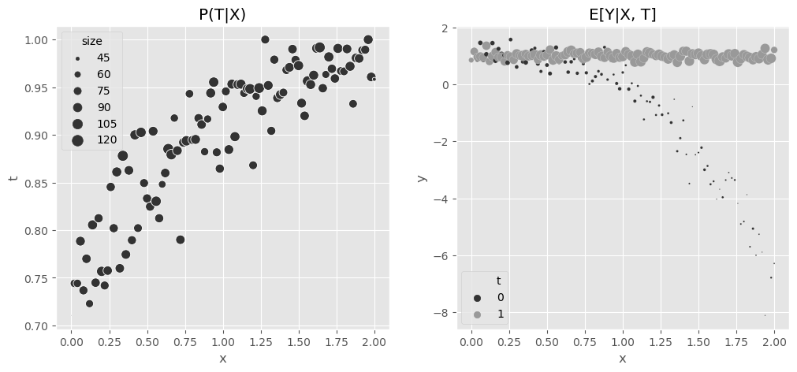

```python
fig, (ax1, ax2) = plt.subplots(1, 2, figsize=(12,5))

sns.scatterplot(data=(df_easy_t
                      .assign(size=1)
                      .groupby(["x"])
                      .agg({"size":"sum", "t":"mean"})
                      .reset_index()),
                x="x", y="t", sizes=(1, 100), size="size", ax=ax1);
ax1.set_title("P(T|X)")

sns.scatterplot(data=(df_easy_t
                      .assign(size=1)
                      .groupby(["x", "t"])
                      .agg({"size":"sum", "y":"mean"})
                      .reset_index()),
                x="x", y="y", hue="t", sizes=(1, 100), size="size", ax=ax2)

ax2.set_title("E[Y|X, T]")

h,l = ax2.get_legend_handles_labels()
plt.legend(h[0:3],l[0:3])
plt.show()
```

- **$\hat{m_1}$과 $\hat{m_0}$을 각각 적합시키고, 전체 데이터셋인 $N^{-1} \sum(\hat{m_1}(x) - \hat{m_0}(X))$에서 각각의 예측값들의 평균을 취합으로 ATE를 추정**

```python
m0 = smf.ols("y~x", data=df_easy_t.query("t==0")).fit()
m1 = smf.ols("y~x", data=df_easy_t.query("t==1")).fit()
regr_ate = (m1.predict(df_easy_t) - m0.predict(df_easy_t)).mean()

print("Regression ATE:", regr_ate)
```

```
Regression ATE: 1.7866783968330227
```

- 회귀모델은 실제 ATE인 2를 추정하지 못함

  $\rightarrow$ 회귀모델은 대조군에서의 곡률을 제대로 포착하지 못함

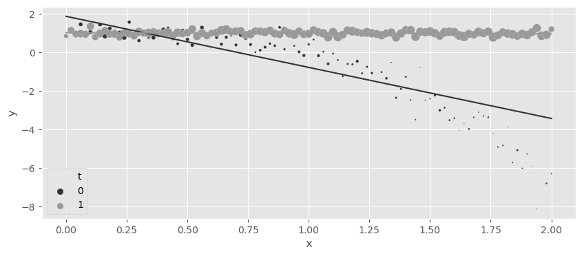

```python
regr = smf.ols("y~x*t", data=df_easy_t).fit()

plt.figure(figsize=(10,4))

sns.scatterplot(data=(df_easy_t
                      .assign(count=1)
                      .groupby(["x", "t"])
                      .agg({"count":"sum", "y":"mean"})
                      .reset_index()),
                x="x", y="y", hue="t", sizes=(1, 100), size="count");

g = sns.lineplot(data=(df_easy_t
                   .assign(pred=regr.fittedvalues)
                   .groupby(["x", "t"])
                   .mean()
                   .reset_index()),
             x="x", y="pred", hue="t", sizes=(1, 100))

h,l = g.get_legend_handles_labels()
plt.legend(h[0:3],l[0:3])
plt.show()
```

- 데이터의 실제 곡률을 알면 정확하게 모델링 할 수 있지만,

  현실에서는 데이터 생성 과정을 정확히 알 수 없음

  $\rightarrow$ 회귀분석은 잘 작동하지 않을 가능성이 높음

#### IPW의 적용

- 처치 배정을 모델링하기 쉬우므로 데이터가 잘 적용됨

```python
def est_ate_with_ps(df, ps_formula, T, Y):

    X = dmatrix(ps_formula, df)
    ps_model = LogisticRegression(max_iter=1000).fit(X, df[T])
    ps = ps_model.predict_proba(X)[:, 1]

    return np.mean((df[T]-ps) / (ps*(1-ps)) * df[Y])
```

```python
est_fn = partial(est_ate_with_ps, ps_formula="x", T="t", Y="y")
print("Propensity Score ATE:", est_fn(df_easy_t))
print("95% CI", bootstrap(df_easy_t, est_fn))
```

```
Propensity Score ATE: 1.991089318939473
95% CI [1.80305132 2.21627653]
```

#### 이중 강건 추정 적용

- $P(T|X)$와 $E[Y_1|X]$중 하나만 정확하면 되며, 두 모델 모두 정확할 필요가 없음

  $\rightarrow$ **순수 IPW와 추정값은 비슷하지만, 95%신뢰구간이 더 좁음**

```python
est_fn = partial(doubly_robust, formula="x", T="t", Y="y")
print("DR ATE:", est_fn(df_easy_t))
print("95% CI", bootstrap(df_easy_t, est_fn))
```

```
DR ATE: 1.99861467745835
95% CI [1.8693554  2.14273047]
```

### 02. 결과 모델링이 쉬운 경우

- 예) 결과 함수는 단순히 선형이지만, $P(T|X)$가 비선형인
  - 실제 ATE는 -1

```python
np.random.seed(123)

n = 10000
x = np.random.beta(1,1, n).round(2)*2
e = 1/(1+np.exp(-(2*x - x**3)))
t = np.random.binomial(1, e)

y1 = x
y0 = y1 + 1 # ate of -1
y = t*(y1) + (1-t)*y0 + np.random.normal(0, 1, n)

df_easy_y = pd.DataFrame(dict(y=y, x=x, t=t))

print("True ATE:", np.mean(y1-y0))
```

```
True ATE: -1.0
```

- $P(T|X)$의 복잡한 함수 형태와 $E[Y_1|X]$의 단순한 함수 형태

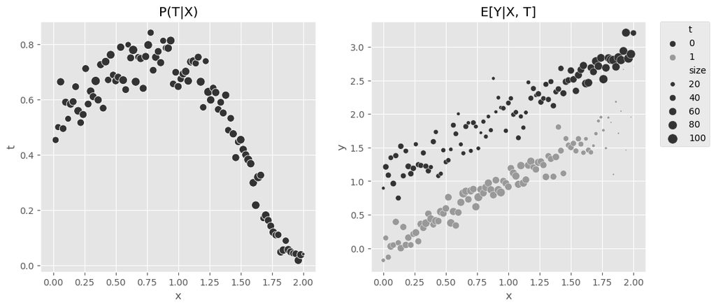

```python
fig, (ax1, ax2) = plt.subplots(1, 2, figsize=(12,5))

sns.scatterplot(data=(df_easy_y
                      .assign(size=1)
                      .groupby(["x"])
                      .agg({"size":"sum", "t":"mean"})
                      .reset_index()),
                x="x", y="t", sizes=(1, 100), size="size", ax=ax1, legend=None);

sns.scatterplot(data=(df_easy_y
                      .assign(size=1)
                      .groupby(["x", "t"])
                      .agg({"size":"sum", "y":"mean"})
                      .reset_index()),
                x="x", y="y", hue="t", sizes=(1, 100), size="size", ax=ax2);

ax1.set_title("P(T|X)")
ax2.set_title("E[Y|X, T]")

plt.legend(bbox_to_anchor=(1.05, 1), loc=2, borderaxespad=0.)
plt.show()
```

#### IPW 적용

- 성향점수 모델링이 상대적으로 복잡하므로, IPW는 실제 ATE를 제대로 추정하기 어려움

```python
est_fn = partial(est_ate_with_ps, ps_formula="x", T="t", Y="y")
print("Propensity Score ATE:", est_fn(df_easy_y))
print("95% CI", bootstrap(df_easy_y, est_fn))
```

```
Propensity Score ATE: -1.104026419971194
95% CI [-1.14292551 -1.06558307]
```

#### 회귀분석 적용

- 비교적 정확한 ATE 추정값

```python
m0 = smf.ols("y~x", data=df_easy_y.query("t==0")).fit()
m1 = smf.ols("y~x", data=df_easy_y.query("t==1")).fit()
regr_ate = (m1.predict(df_easy_y) - m0.predict(df_easy_y)).mean()

print("Regression ATE:", regr_ate)
```

```
Regression ATE: -1.0008783612504373
```

#### 이중 강건 추정 모델 적용

```python
est_fn = partial(doubly_robust, formula="x", T="t", Y="y")
print("DR ATE:", est_fn(df_easy_y))
print("95% CI", bootstrap(df_easy_y, est_fn))
```

```
DR ATE: -1.0028376266139374
95% CI [-1.0415416  -0.96353624]
```

## 05.06. 연속형 처치에서의 일반화 성향점수

- **이산형 처치보다 연속형 처치가 다루기 훨씬 더 복잡하며, 이 문제에 대한 확실한 인과추론적 해결책은 없음**

  성향점수 가중치에서 모수적 반응 함수와 같은 것은 존재하지 않으며, 잠재적 결과는 재조정하고 평균을 구하는 형태인 비모수적 방식으로 추정됨
- **$T$가 연속형일 때 잠재적 결과 $Y_1$는 무한히 존재하며, 연속형 변수의 확률은 항상 0이므로, 이 시나리오에서는 $P(T=t|X)$를 추정할 수 없음**

  (= 연속형은 "정확히 그 값"이 나올 확률이 0)

  $\rightarrow$ **이러한 문제를 해결하는 가장 간단한 방법은 연속형 처치를 이산화 하거나, 혹은 일반화 성향점수 (Generalized Propensity Score, GPS)를 사용**

### 일반화 성향 점수 (GPS)

- 일반 성향점수(PS)와 일반화 성향점수 (GPS)의 가중치
  - **이산형 (기존 IPW) : $W = \frac{1}{P(T=t|X)}$**
  - **연속형 (GPS) : $W = \frac{1}{f(T=t|X)}$**

#### 은행 금리 예시

> 직관적으로 금리가 대출 상환기간에 미치는 영향은 음수여야함

> 사람들은 이자 지불을 최소화하려고 고금리 대출을 가능한 빨리 상환하고 싶어하기 때문

> 은행이 금리를 무작위로 배정하는 것은 비현실적 $\rightarrow$ 기존의 데이터를 사용

> 은행은 금리를 두 가지 머신러닝 모델 `ml_1`과 `ml_2`에 따라 배정하며, 금리 결정 과정에 임의의 가우스 잡음 (Gaussian Noise)을 추가하여 양수성 가정을 위배하지 않도록 설정

> 관측(비무작위) 이자 데이터에는 교란 요인인 `ml_1`, `ml_2`, 상환기간 (`duration`) 정보가 존재

```python
df_cont_t = pd.read_csv("./data/interest_rate.csv")

df_cont_t.head()
```

|  | ml_1 | ml_2 | interest | duration |
| --- | --- | --- | --- | --- |
| 0 | 0.392938 | 0.326285 | 7.1 | 12.0 |
| 1 | -0.427721 | 0.679573 | 5.6 | 17.0 |
| 2 | -0.546297 | 0.647309 | 11.1 | 12.0 |
| 3 | 0.102630 | -0.264776 | 7.2 | 18.0 |
| 4 | 0.438938 | -0.648818 | 9.5 | 19.0 |

- **목표는 금리와 상환기간 사이의 관계가 편향되지 않도록 `ml_`과 `ml_2`를 보정하는 것**

  $\rightarrow$ **보정하지 않고 단순히 추정하면 양의 처치효과를 얻게되며, 이는 편향된 결과 일 수 있음**

```python
m_naive = smf.ols("duration ~ interest", data=df_cont_t).fit()
m_naive.summary().tables[1]
```

|  | coef | std err | t | P>\|t\| | [0.025 | 0.975] |
| --- | --- | --- | --- | --- | --- | --- |
| Intercept | 14.5033 | 0.226 | 64.283 | 0.000 | 14.061 | 14.946 |
| interest | 0.3393 | 0.029 | 11.697 | 0.000 | 0.282 | 0.396 |

- **가장 먼저 해결해야할 문제는 연속형 변수가 어디서나 확률이 0이라는 것 $P(T=t) = 0$**

  **이는 확률이 밀도 아래의 면적으로 표현되고, 한 점의 면적은 항상 0이기 때문에 발생**

  $\rightarrow$ **가능한 해결책 중 하나는 조건부 확률 $P(T=t|X)$ 대신 조건부 밀도함수 $f(T|X)$를 사용하는 것**

  $\rightarrow$ **이 접근법은 처치 분포를 정해야 한다는 또 다른 문제가 존재**
- 처치가 정규분포에서 추출되었다고 가정 $T \sim N(\mu, \sigma^2)$

  (이분산성이 아닌 등분산 $\sigma^2$가정)

$$f(t_1) = \frac{\exp(-\frac{1}{2}(\frac{t_1 - \mu_1}{\sigma})^2 )}{\sigma \sqrt{2\pi}}$$

- **조건부 정규분포의 매개변수인 평균과 표준편차의 추정**

  $\rightarrow$ **가장 간단한 방법은 OLS를 사용하여 처치 (`interest`)를 적합시키는 것**

```python
model_t = smf.ols("interest~ml_1+ml_2", data=df_cont_t).fit()
```

- **적합된 값을 $\mu_1$로 사용하고, 잔차의 표준편차를 $\sigma$로 사용 $\rightarrow$ 조건부 밀도 함수의 추정값을 얻을 수 있음**

  $\rightarrow$ 처치에 해당하는 조건부 밀도를 평가

  $\rightarrow$ 밀도함수의 `x`인수에 $T$를 전달

```python
def conditional_density(x, mean, std):
    denom = std*np.sqrt(2*np.pi)
    num = np.exp(-((1/2)*((x-mean)/std)**2))
    return (num/denom).ravel()
```

```python
gps = conditional_density(df_cont_t["interest"], model_t.fittedvalues, np.std(model_t.resid))
gps

# from scipy.stats import norm
# gps = norm(loc=model_t.fittedvalues,
#            scale=np.std(model_t.resid)).pdf(df_cont_t["interest"])
# gps
```

```
array([0.1989118 , 0.14524168, 0.03338421, ..., 0.07339096, 0.19365006,
       0.15732008])
```

- **회귀분석에서 일반화 성향점수의 역수를 가중치로 사용하면 편향을 보정할 수 있음**

```python
final_model = smf.wls("duration~interest", data=df_cont_t, weights=1/gps).fit()

final_model.params["interest"]
```

```
-0.6673977919925834
```

- 일반화 성향점수를 사용하여 가중치를 구성하면, 일반적으로 처치 가능성이 낮은 포인트에 더 큰 중요도를 부여할 수 있음
  - 적합된 처치 모델에서 잔차가 큰 실험 대상에 높은 가중치를 할당
- 또한, 정규분포의 지수적 특성 때문에 가중치는 잔차의 크기에 따라 기하급수적으로 증가
- **첫 번째 그래프는 원본 데이터를 교란 요인 `ml_1`에 따라 색상으로 구분**
  - `ml_1`점수가 낮은 고객은 일반적으로 대출 상환기간을 길게 선택
  - `ml_1`점수가 낮은 고객에게는 더 높은 금리가 배정

  $\rightarrow$ 결과적으로 금리와 상환기간 간의 관계에는 상향 편향이 존재
- **두 번째 그래프는 처치 모델의 적합된 값과, 해당 모델에서 얻은 일반화 성향점수로 구성된 가중치**
  - **가중치는 적합된 선에서 멀어질수록 커지며, 이는 일반화 성향점수가 가능성이 낮은 처치에 더 많은 가중치를 부여하기 때문**
- **세 번째 그래프는 가중치를 동일하게 유지하면서 금리와 상환기간의 관계**
  - `ml_1`의 낮은 값에서 낮은 금리와, `ml_1`의 높은 값에서 높은 이자율이 모두 드물게 나타나므로, 일반화 성향점수 가중치의 역수는 이러한 포인트에 높은 중요도를 부여

$\rightarrow$ **금리와 상환기간 간의 양의(편향된)관계를 뒤집을 수 있음**

```python
from scipy.stats import norm
```

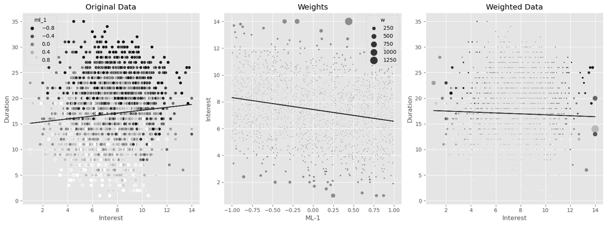

```python
np.random.seed(1)
sample = df_cont_t.sample(2000)

model_ex = smf.ols("interest~ml_1", data=sample).fit()
gps_ex = norm(loc=model_ex.fittedvalues, scale=np.std(model_ex.resid)).pdf(sample["interest"])

w_ex = 1/gps_ex

m = smf.ols("duration~interest", data=sample).fit()

fig, (ax1, ax2, ax3) = plt.subplots(1, 3, figsize=(16, 6))

sns.scatterplot(data=sample, x="interest", y="duration", alpha=1, ax=ax1, hue="ml_1", palette = 'gray')
ax1.plot(sample["interest"], m.fittedvalues)

ax1.set_ylabel("Duration")
ax1.set_xlabel("Interest")
ax1.set_title("Original Data");


sns.scatterplot(data=sample.assign(w=w_ex), x="ml_1", y="interest",size="w",
                sizes=(1,200), alpha=0.5, ax=ax2)
ax2.plot(sample["ml_1"], model_ex.fittedvalues)
ax2.set_ylabel("Interest")
ax2.set_xlabel("ML-1")
ax2.set_title("Weights")


m = smf.wls("duration~interest", data=sample, weights=w_ex).fit()

sns.scatterplot(data=sample.assign(w=w_ex), x="interest", y="duration",size="w",
                sizes=(1,200), alpha=1, ax=ax3, hue="ml_1", legend=None, palette = 'gray')
ax3.plot(sample["interest"], m.fittedvalues)
ax3.set_ylabel("Duration")
ax3.set_xlabel("Interest")
ax3.set_title("Weighted Data")

plt.tight_layout()
plt.show()
```

### 일반화 성향점수의 가중치 안정화

- **이산형 처치에서 가중치 안정화는 선택사항이었지만, 연속형 처치에서 일반화 성향점수를 사용할 때는 필수**
  - $f(t)$ 추정에는 평균 처칫값을 사용하며, 처치가 주어진 경우, 밀도함수에 대한 결과를 평가

  $\rightarrow$ 가중치들은 $f(t|x)$에서 $f(t)$로 이동

$$w = \frac{f(T=t)}{f(T=t|X)}$$

```python
stabilizer = norm(
    loc=df_cont_t["interest"].mean(),
    scale=np.std(df_cont_t["interest"] - df_cont_t["interest"].mean())
).pdf(df_cont_t["interest"])

gipw =  stabilizer/gps

print("Original Sample Size:", len(df_cont_t))
print("Effective Stable Weights Sample Size:", sum(gipw))
```

```
Original Sample Size: 10000
Effective Stable Weights Sample Size: 9988.195951748608
```

- 안정화된 가중치로 인하여 실제 ATE인 -0.8에 더 가까운 추정값을 얻음

```python
final_model = smf.wls("duration ~ interest", data=df_cont_t, weights=gipw).fit()

final_model.params["interest"]
```

```
-0.7787046278134032
```

- **$T$가 이산형인 경우에서 가중치 안정화는 큰 영향을 미치지 않았지만, 연속형 처치에서는 매우 중요**
  - 가중치 안정화는 추정하려는 실제 매개변수 값에 더 가까워지게 하고 분산도 크게 줄여줌
- 부트스트랩을 적용한 95% 신뢰구간
  - 안정화를 적용했을 때 신뢰구간이 더 좁음

```python
def gps_normal_ate(df, formula, T, Y, stable=True):
    mt = smf.ols(f"{T}~"+formula, data=df).fit()
    gps = norm(loc=mt.fittedvalues, scale=np.std(mt.resid)).pdf(df[T])
    stabilizer = norm(
        loc=df[T].mean(),
        scale=np.std(df[T] - df[T].mean())
    ).pdf(df[T])

    if stable:
        return smf.wls(f"{Y}~{T}", data=df, weights=stabilizer/gps).fit().params[T]
    else:
        return smf.wls(f"{Y}~{T}", data=df, weights=1/gps).fit().params[T]
```

```python
print("95% CI, 안정화 미적용: ", bootstrap(df_cont_t, partial(gps_normal_ate, formula="ml_1 + ml_2", T="interest", Y="duration", stable=False)))
print("95% CI, 안정화 적용: ", bootstrap(df_cont_t, partial(gps_normal_ate, formula="ml_1 + ml_2", T="interest", Y="duration")))
```

```
95% CI, 안정화 미적용:  [-0.81074164 -0.52605933]
95% CI, 안정화 적용:  [-0.85834311 -0.71001914]
```

#### 정규분포 이외의 경우

- 처치가 정규분포가 아닌 다른 분포를 따른다면, 일반화선형모델 (Generalized Linear Model, GLM)을 사용하여 이를 적합할 수 있음
- 예) $T$가 푸아송 분포 (Poisson Distribution)에 따라 배정된 경우, 일반화 성향점수의 가중치

```
import statsmodels.api as sm
from scipy.stats import poisson

mt = smf.glm("t~x1+x2", data=df, family=sm.families.Poisson()).fit()

gps = poisson(mu=m_pois.fittedvalues).pmf(df["t"])

w = 1/gps
```

## 05.07. 요약

- 인과추론에서 회귀분석 및 직교화와 함께, 역확률 가중치 (IPW)는 편향을 보정하는 핵심 방법

  두 방법 모두 처치를 모델링해야하며, 이는 인과추론 문제에서 처치 배정 메커니즘을 생각하는 것이 얼마나 중요한지 알려줌
1. **직교화 (Orthogonalization): "편향을 깎아내기"**
- 직교화는 회귀분석의 핵심 원리
- 방식: 처치($T$)에서 공변량($X$)으로 설명 가능한 부분을 빼버리고 남은 **잔차(Residual)** 만 사용

  $\rightarrow$ 처치와 모든 공변량을 하나의 식으로 적합
- 비유: 조각가가 돌덩이(데이터)에서 불필요한 부분($X$의 영향)을 깎아내어, 우리가 보고 싶은 순수한 형상(인과 효과)만 남기는 것과 동일
- 결과: 새로 만들어진 처치 변수는 $X$와 통계적으로 아무런 상관이 없는(직교하는) 상태
2. **IPW (Inverse Propensity Weighting): "데이터를 다시 섞기"**
- IPW는 데이터의 형태를 바꾸는 것이 아니라, 각 데이터의 **영향력(가중치)** 을 조절
- 방식: 성향점수의 역수를 곱해, 특정 특성($X$)을 가진 사람이 처치를 받을 확률이 모두 동일해지도록 가중치를 부여
- 비유: 편향된 표본이 섞인 카드 덱에서, 부족한 카드는 여러 장인 것처럼 취급하고 너무 많은 카드는 한 장처럼 취급하여 완벽하게 공정한 덱을 다시 만드는 것과 동일
- **결과: 데이터 세트 전체가 마치** 무작위 배정 실험(RCT)**을 통해 얻어진 것과 같은 분포($P(T)$)로 변모**
- **이산형(0/1)일 때 IPW가 좋은 이유**
  - 상황: "약을 먹었다(1)" vs "안 먹었다(0)"처럼 딱 두 그룹만 존재
  - 이유: 각 그룹에 데이터가 충분히 쌓여 있으며. 굳이 "약 0.5알 먹으면 어떨까?" 같은 복잡한 예측(모델링)을 할 필요 없이, 그냥 있는 데이터를 **가중치(IPW)** 로 잘 섞어서 비교하는 게 더 정확하고 깔끔함
  - 이중 강건(Doubly Robust): 여기에 회귀분석까지 곁들이면, 둘 중 하나만 맞춤형이어도 인과 효과를 맞출 수 있는 강력한 시너지
- **연속형(양)일 때 회귀분석을 선호하는 이유**
  - 연속형(예: 약 10.1mg, 10.2mg, 10.3mg...)에서는 상황이 완전히 달라짐
  - 데이터 부족 문제
    - 예) 연속형에서는 "정확히 12.57mg을 복용한 사람"은 전 세계에 단 한 명뿐이거나 아예 없을 수도 있음
  - IPW의 한계: IPW는 그 지점에 있는 데이터를 가중치로 부풀려야 하는데, 데이터가 너무 적으면(희박하면) 가중치를 아무리 줘봤자 신뢰도가 떨어짐
  - 회귀분석의 '평활도(Smoothing)' 가정
    - 회귀분석의 장점: "12mg 효과가 이렇고 13mg 효과가 저렇다면, 그 사이인 12.5mg 효과는 대충 이 선 위에 있겠지?"라고 **부드러운 선(평활도)**을 산정 가능

  $\rightarrow$ **즉, 주변 데이터(12mg, 13mg)의 힘을 빌려서 데이터가 없는 지점(12.5mg)을 추측가능 $\rightarrow$ '모수적 가정'**

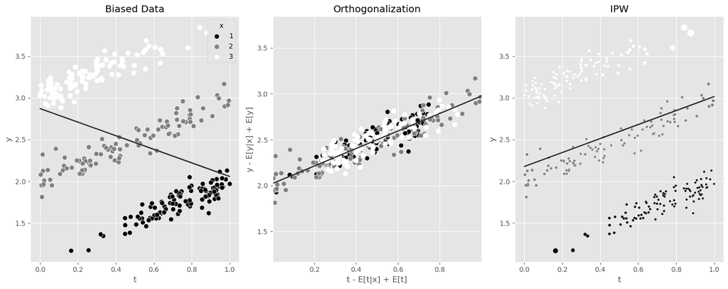

```python
np.random.seed(1)

n=100

df1 = pd.DataFrame(dict(
    x=1,
    t=np.random.beta(2.5,1, n),
)).assign(y = lambda d: np.random.normal(d["x"]+d["t"], 0.1))

df2 = pd.DataFrame(dict(
    x=2,
    t=np.random.beta(1,1, n),
)).assign(y = lambda d: np.random.normal(d["x"]+d["t"], 0.1))

df3 = pd.DataFrame(dict(
    x=3,
    t=np.random.beta(1,2.5, n),
)).assign(y = lambda d: np.random.normal(d["x"]+d["t"], 0.1))


df_example = pd.concat([df1, df2, df3])

fig, (ax1, ax2, ax3) = plt.subplots(1, 3, figsize=(15,6))

m = smf.ols("y~t", data=df_example).fit()
sns.scatterplot(data=df_example, x="t", y="y",  hue="x", s=50, ax=ax1, palette = 'gray')
ax1.plot(df_example["t"], m.fittedvalues)
ax1.set_title("Biased Data")

## Orthogonalization

mt = smf.ols("t~x", data=df_example).fit()
my = smf.ols("y~x", data=df_example).fit()

df_ex_res = df_example.assign(
    t_res = mt.resid + df_example["t"].mean(),
    y_res = my.resid + df_example["y"].mean()
)

m_final = smf.ols("y_res~t_res", data=df_ex_res).fit()
sns.scatterplot(data=df_ex_res, x="t_res", y="y_res",  hue="x", s=50, ax=ax2, legend=None, palette = 'gray')
ax2.plot(df_ex_res["t_res"], m_final.fittedvalues)

ax2.set_ylim(df_example["y"].min(), df_example["y"].max())
ax2.set_xlim(df_example["t"].min(), df_example["t"].max())

ax2.set_ylabel("y - E[y|x] + E[y]")
ax2.set_xlabel("t - E[t|x] + E[t]")
ax2.set_title("Orthogonalization")


## IPW
gps_example = norm(loc=mt.fittedvalues, scale=np.std(mt.resid)).pdf(df_example["t"])
stabilizer_example = norm(
    loc=df_example["t"].mean(),
    scale=np.std(df_example["t"] - df_example["t"].mean())
).pdf(df_example["t"])


w_example = stabilizer_example/gps_example
mw = smf.wls("y~t", data=df_example, weights=w_example).fit()


sns.scatterplot(data=df_example.assign(w=w_example), x="t", y="y",  hue="x", ax=ax3, size="w",
                legend=None, sizes=(11,100), palette = 'gray')
ax3.plot(df_example["t"], mw.fittedvalues)
ax3.set_title("IPW")

plt.tight_layout()
plt.show()
```